# Improving Image Processing for Electron Diffraction Pattern Models

## Abstract

The field of materials science heavily relies on electron diffraction patterns to characterize the crystal structure of materials. Accurately analyzing these patterns is critical, and the efficiency and accuracy of image processing algorithms play a significant role in this analysis. In order to improve the performance of these algorithms, this project aims to address several key challenges in the image processing of electron diffraction pattern datasets. The project will focus on developing a graph model for accurate point detection, adding synthetic noise to simulated patterns to make them more representative of real data, denoising the input images to enhance their accuracy, and evaluating the performance of the image processing algorithms on real data. The goal of this project is to contribute to the field of materials science by improving the accuracy and efficiency of electron diffraction pattern analysis.

## Introduction

- Materials science relies on electron diffraction patterns to analyze crystal structure.
- Accurate analysis of these patterns is essential, and image processing algorithms play a significant role in this analysis.
- Objective: Improve machine learning models for analyzing selected area electron diffraction (SAED) patterns.

### What is Electron Diffraction and Why is it Important?

- Electron diffraction examines the atomic structure of materials.
- A beam of electrons is fired at a sample and a diffraction pattern is observed.
- The pattern reveals the crystal structure, symmetry, and different phases of the material.
- Identifying crystal structure, symmetry, and phases helps predict behavior and properties.
- Electron diffraction is used to analyze various types of materials, from metals to ceramics to polymers.
- It is a powerful tool for gaining insights and advancing the field of materials science.

### Aim 1

- Develop a Graph Model for Point Detection The first aim of the project is to develop a graph model for locating the points in electron diffraction patterns.
- The model should be able to accurately locate the center of the image and crop the image to a 512x512 pixel resolution.
- This is important because accurate detection of points is crucial for the proper analysis of electron diffraction patterns and also to expedite the process and reduce human workload.

### Data Science Methods

Machine learning, statistical analysis, and image processing are some of the data science techniques that will be used. The project will specifically involve creating a graph model for precise point detection, adding synthetic noise to simulated patterns to make them more resemblant of real data, and testing the effectiveness of the image processing algorithms on actual data.

## Exploratory Data Analysis

### The Data

- Professor Assel Aitkaliyeva of the University of Florida provided the datasets, which were then used by Nathaniel K. TOMCZAK,

a graduate student researcher at the Mesoscale Science Lab of Case Western Reserve University, to complete his master's thesis.

- First dataset consists of 865 selected area electron diffraction (SAED) patterns from two plutonium

(Pu) and zirconium (Zr) alloy systems: Pu with 10 weight percent Zr (Pu-10Zr) and Pu with 30 weight percent Zr (Pu-30Zr).

- The SAED patterns were categorized into three classes: 364 alpha

patterns, 282 delta patterns, and 219 other patterns. The space group and corresponding lattice parameters for each pattern are also provided.

- The second dataset rotated each pattern before cropping by 15◦ increments 23 times,

scaling the original dataset by a factor of 24.

- There were 20,760 images spread between the three classes as follows:

8,736 alpha patterns, 6,768 delta patterns, and 5,256 other patterns.

### Data Cleaning

```python
from docx import Document
from tabulate import tabulate

document = Document('/Users/iuruc/OneDrive/Desktop/GIT/project/rawdata/Pu-Zr experimentally observed phases.docx')
tables = [table for table in document.tables]

table_data = {table.rows[0].cells[0].text.strip():
              {"headers": [cell.text.strip() for cell in table.rows[1].cells],
               "rows": [[cell.text.strip() for cell in row.cells] for row in table.rows[2:]]} for table in tables}

for table_name, table in table_data.items():
    print(f"{table_name}")
    print(tabulate(table['rows'], headers=table['headers'], tablefmt="grid"))
    print()
```

```
Pu-10Zr alloy
+-----------+-----------+------------+---------------+------------------------------------------+
| Phase     | As-cast   | Annealed   | Space group   | Lattice parameters                       |
+===========+===========+============+===============+==========================================+
| α-Zr      | X         | X          | P63/mmc       | a=b=0.32±0.001; c=0.51±0.001             |
+-----------+-----------+------------+---------------+------------------------------------------+
| ZrO2      | X         | X          | P21/c         | a=0.51±0.001; b=0.52±0.001; c=0.53±0.001 |
+-----------+-----------+------------+---------------+------------------------------------------+
| Zr3O      | X         | -          | R32 h         | a=b=0.56±0.001; c=3.14±0.001             |
+-----------+-----------+------------+---------------+------------------------------------------+
| Zr3O      | X         | -          | R-3c h        | a=b=0.56±0.001; c=1.57±0.001             |
+-----------+-----------+------------+---------------+------------------------------------------+
| PuO       | X         | -          | Fm-3m         | a=b=c=0.49±0.002                         |
+-----------+-----------+------------+---------------+------------------------------------------+
| PuO2      | -         | X          | Fm-3m         | a=b=c=0.53±0.002                         |
+-----------+-----------+------------+---------------+------------------------------------------+
| δ-(Pu,Zr) | X         | X          | Fm-3m         | a=b=c=0.45±0.001                         |
+-----------+-----------+------------+---------------+------------------------------------------+
| κ-PuZr2   | X         | -          | P6/mmm        | a=b=0.50±0.001; c=0.312±0.001            |
+-----------+-----------+------------+---------------+------------------------------------------+
| δ'-Pu     | -         | X          | Fm-3m         | a=b=c=0.46±0.003                         |
+-----------+-----------+------------+---------------+------------------------------------------+
| β-Pu      | -         | X          | C12/m1        | a=1.18±0.002; b=1.04±0.002; c=0.78±0.002 |
+-----------+-----------+------------+---------------+------------------------------------------+

Pu-30Zr alloy
+-----------+-----------+------------+---------------+------------------------------------------+
| Phase     | As-cast   | Annealed   | Space group   | Lattice parameters                       |
+===========+===========+============+===============+==========================================+
| α-Zr      | X         | X          | P63/mmc       | a=b=0.32±0.001; c=0.51±0.001             |
+-----------+-----------+------------+---------------+------------------------------------------+
| ZrO2      | X         | X          | P21/c         | a=0.51±0.001; b=0.52±0.001; c=0.53±0.001 |
+-----------+-----------+------------+---------------+------------------------------------------+
| δ-(Pu,Zr) | X         | X          | Fm-3m         | a=b=c=0.45±0.001                         |
+-----------+-----------+------------+---------------+------------------------------------------+
```

#### Pu-Zr Experimentally Observed Phase

- Phase: This column refers to the different phases or materials that were present in the alloy samples.
- As-cast: This column indicates whether the sample was tested in its as-cast state, which means it was tested in the state it was produced.
- Annealed: This column indicates whether the sample was tested after annealing, which is a process that involves heating the sample

to a high temperature and then slowly cooling it down to change its properties.

- Space group: This column indicates the specific crystal structure or arrangement of atoms in the material.
- Lattice parameters: This column provides information on the size and shape of the crystal structure,

which is determined by the lattice parameters such as the length of the edges of the unit cell that make up the crystal.

```python
import os
path = "/Users/iuruc/OneDrive/Desktop/GIT/project/rawdata"
for item in os.scandir(path):
    if item.is_file():
        print("File: " + item.name)
    elif item.is_dir():
        print("Directory: " + item.name + "/")
        for sub_item in os.scandir(item.path):
            if sub_item.is_file():
                print("\tFile: " + sub_item.name)
            elif sub_item.is_dir():
                print("\tDirectory: " + sub_item.name + "/")
```

```
Directory: Pu-10Zr/
	Directory: 1A as-cast/
	Directory: 1A as-cast simulated/
	Directory: 1D as-cast/
	Directory: 1D as-cast simulated/
	Directory: 2A as-cast/
	Directory: 2A exp annealed/
	Directory: 2B exp annealed/
	Directory: 2C exp annealed/
	Directory: 2D as-cast/
	Directory: 2D exp annealed/
	File: Pu-10Zr info combined.xlsx
Directory: Pu-30Zr/
	Directory: 1A exp annealed/
	Directory: 1A exp as-cast/
	Directory: 1D exp as-cast/
	Directory: 2B exp as-cast/
	Directory: 2C exp as-cast/
	File: Pu-30Zr info combined.xlsx
File: Pu-Zr experimentally observed phases.docx
```

```python
import pandas as pd
df = pd.read_excel("/Users/iuruc/OneDrive/Desktop/GIT/project/rawdata/Pu-10Zr/Pu-10Zr info combined.xlsx")
print(df.head())
```

```
  Folder name                           Image ID   Phase ID Zone axis
0  1A as-cast   01_zxxx_CL175mm_x=-8.98, y=-7.75  δ-(Pu,Zr)     [001]
1  1A as-cast  01_zxxx_CL175mm_x=-23.44, y=-5.11  δ-(Pu,Zr)    [1-14]
2  1A as-cast   01_zxxx_CL175mm_x=-23.44, y=7.26  δ-(Pu,Zr)     [013]
3  1A as-cast      01_zxxx_CL175mm_x=-24, y=8.36  δ-(Pu,Zr)     [013]
4  1A as-cast    01_zxxx_CL175mm_x=1.62, y=16.66  δ-(Pu,Zr)   [0-1-3]
```

- The table shows the diffraction patterns of different phases of a material, where the zone axis describes the orientation of the crystal relative to the x, and y axes.
- These diffraction patterns are taken from images of the material under various conditions such as as-cast or annealed.

#### Looking Into Dataset

```python
# Now lets look into the first folder

folder = '/Users/iuruc/OneDrive/Desktop/GIT/project/rawdata/Pu-10Zr/1A as-cast'
images = os.listdir(folder)

table = [[i+1, images[i]] for i in range(5)] + \
        [[len(images)-4+j, images[len(images)-5+j]] for j in range(5)]

print(tabulate(table, headers=["Image ID", "Filename"]))
```

```
  Image ID  Filename
----------  --------------------------------------------------------------------------------------------------------
         1  01_zxxx_CL175mm_x=-23.44, y=-5.11.tif
         2  01_zxxx_CL175mm_x=-23.44, y=7.26.tif
         3  01_zxxx_CL175mm_x=-24, y=8.36.tif
         4  01_zxxx_CL175mm_x=-8.98, y=-7.75.tif
         5  01_zxxx_CL175mm_x=1.62, y=16.66.tif
        97  Transmission Electron Diffraction- 20_zxxx_CL175mm_x=0.25, y=6.1 Image delta-Pu,Zr [-1-1-2] Angle 50.tif
        98  Transmission Electron Diffraction- 20_zxxx_CL175mm_x=0.25, y=6.1 Image delta-Pu,Zr [-1-1-2] Angle 60.tif
        99  Transmission Electron Diffraction- 20_zxxx_CL175mm_x=0.25, y=6.1 Image delta-Pu,Zr [-1-1-2] Angle 70.tif
       100  Transmission Electron Diffraction- 20_zxxx_CL175mm_x=0.25, y=6.1 Image delta-Pu,Zr [-1-1-2] Angle 80.tif
       101  Transmission Electron Diffraction- 20_zxxx_CL175mm_x=0.25, y=6.1 Image delta-Pu,Zr [-1-1-2] Angle 90.tif
```

- The x and y values in the filenames likely correspond to the location at which the image was taken.
- These values may be coordinates on a stage or platform on which the specimen was placed during imaging,

or they may refer to the position of the electron beam during imaging.

### Experimental vs Simulated

#### Visuals and Differences

```python
from IPython.display import display
import matplotlib.pyplot as plt
import os

def my_function():
    dir_path = "/Users/iuruc/OneDrive/Desktop/GIT/project/rawdata/Pu-10Zr/1A as-cast"
    files = os.listdir(dir_path)

    fig, axes = plt.subplots(1, 2, figsize=(14, 7))

    # Display the first image with a number prefix
    for i in range(len(files)):
        if files[i].startswith(('01', '02')):
            img = plt.imread(f'{dir_path}/{files[i]}')
            axes[0].imshow(img)
            axes[0].set_title(files[i][:20])
            break

    # Displaying the first image starting with "Transmission Electron Diffraction"
    for i in range(len(files)):
        if files[i].startswith('Transmission Electron Diffraction'):
            img = plt.imread(f'{dir_path}/{files[i]}')
            axes[1].imshow(img)
            axes[1].set_title(files[i][:20])
            break

    plt.show()
    return None
```

[figure not shown]

[output not shown]

```python
my_output = my_function()
display(my_output)
```

- This will display two images side by side, one with a file name starting with a number and one starting with

"Transmission Electron Diffraction".

- The set_title() method is used to display only the first 20 characters of the file name as the title, so that the full name does not take up too much space.
- Here we see that in this folder there are real images and also simulated images.
- Also found that 61 files have 2677344 pixels and 40 files have 1302292 pixels in this 1 folder which means real and simulated images are different size.

```python
import os
import tifffile

root_path = "/Users/iuruc/OneDrive/Desktop/GIT/project/rawdata/"

image_paths = []

for dirpath, dirnames, filenames in os.walk(root_path):
    for filename in filenames:
        if filename.endswith(".tif"):
            image_paths.append(os.path.join(dirpath, filename))
image = tifffile.imread(image_paths[0])
```

```python
print(f"Image shape: {image.shape}")
print(f"Image data type: {image.dtype}")
print(f"Image max pixel value: {image.max()}")
print(f"Image min pixel value: {image.min()}")
```

```
Image shape: (1336, 2004)
Image data type: uint8
Image max pixel value: 255
Image min pixel value: 0
```

```python
import numpy as np

image_mean = np.mean(image)
image_std = np.std(image)

print("Image mean:", image_mean)
print("Image standard deviation:", image_std)
```

```
Image mean: 48.26778777773794
Image standard deviation: 22.830947858093005
```

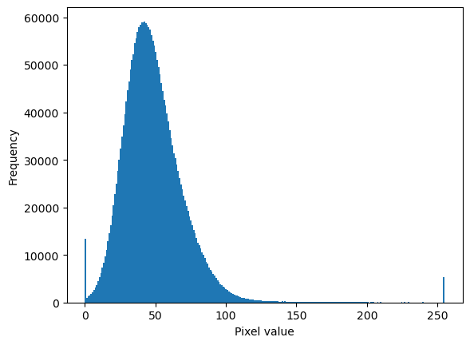

```python
import matplotlib.pyplot as plt

plt.hist(image.ravel(), bins=256, range=(0, 255))
plt.xlabel('Pixel value')
plt.ylabel('Frequency')
plt.show()
```

```python
import os
import tifffile

folder_path = "/Users/iuruc/OneDrive/Desktop/GIT/project/rawdata/"
image_properties = {}

# Looping over all subdirectories and images
for root, dirs, files in os.walk(folder_path):
    for file in files:
        if file.endswith(".tif"):
            image_path = os.path.join(root, file)
            image = tifffile.imread(image_path)
            image_shape = image.shape
            image_dtype = str(image.dtype)
            image_max = image.max()
            image_min = image.min()

            # Add the image properties to the dictionary
            image_key = (image_shape, image_dtype, image_max, image_min)
            if image_key in image_properties:
                image_properties[image_key] += 1
            else:
                image_properties[image_key] = 1

# Printing the number of images with each set of properties
for key, value in image_properties.items():
    print(f"{key}: {value} images")
```

```
((1336, 2004), 'uint8', 255, 0): 551 images
((844, 1543, 4), 'uint8', 255, 0): 251 images
((844, 1551, 4), 'uint8', 255, 0): 830 images
((1334, 2004), 'uint8', 255, 0): 327 images
```

```
Real image shape: (1336, 2004)
Real image data type: uint8
Simulated image shape: (844, 1543)
Simulated image data type: uint8
```

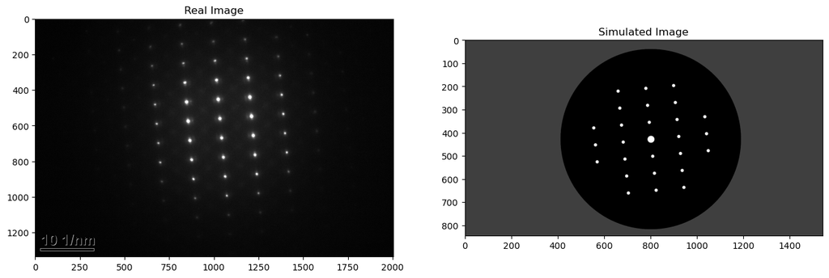

```python
import numpy as np
import matplotlib.pyplot as plt
from PIL import Image

# Loading the real and simulated images
real_image = np.array(Image.open('C:/Users//iuruc/OneDrive/Desktop/GIT/project/rawdata/Pu-10Zr/1A as-cast/20_zxxx_CL175mm_x=0.25, y=6.1.tif').convert('L'))
simulated_image = np.array(Image.open('C:/Users//iuruc/OneDrive/Desktop/GIT/project/rawdata/Pu-10Zr/1A as-cast/Transmission Electron Diffraction- 20_zxxx_CL175mm_x=0.25, y=6.1 Image delta-Pu,Zr [-1-1-2] Angle 00.tif').convert('L'))

# Printing the shape and data type of the images
print('Real image shape:', real_image.shape)
print('Real image data type:', real_image.dtype)
print('Simulated image shape:', simulated_image.shape)
print('Simulated image data type:', simulated_image.dtype)

# Displaying the images side by side
fig, ax = plt.subplots(nrows=1, ncols=2, figsize=(16, 16))
ax[0].imshow(real_image, cmap='gray')
ax[0].set_title('Real Image')
ax[1].imshow(simulated_image, cmap='gray')
ax[1].set_title('Simulated Image')
plt.figure(figsize=(20, 20))
plt.show()
```

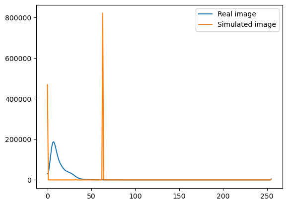

```python
# Comparing the pixel values of the two images
real_hist, _ = np.histogram(real_image, bins=256)
simulated_hist, _ = np.histogram(simulated_image, bins=256)

plt.plot(real_hist, label='Real image')
plt.plot(simulated_hist, label='Simulated image')
plt.legend()
plt.show()
```

The next step is to calculate the entropy of the two images.To do this, we can use the entropy function from the scipy module. The entropy is a measure of the randomness and complexity of the image. The higher the entropy, the more random and complex the image is.

```python
from scipy.stats import entropy

real_entropy = entropy(real_image)
simulated_entropy = entropy(simulated_image)

print('Real image entropy:', real_entropy)
print('Simulated image entropy:', simulated_entropy)
```

```
Real image entropy: [6.98613008 7.00299661 7.00963621 ... 7.06376016 7.06024204 7.06698228]
Simulated image entropy: [6.73801766 6.73797722 6.73797722 ... 6.73797722 6.73797722 6.73797722]
```

The entropy values indicate the amount of randomness or uncertainty in the image. Higher entropy values indicate greater randomness and unpredictability in the image. Therefore, it can be concluded that the real images have a higher degree of randomness or entropy compared to the simulated images.

Next, we can analyze the spatial frequency of the two images. One way to do this is by calculating the Discrete Fourier Transform (DFT) of the images, which will give us an idea of the frequency content in the images.

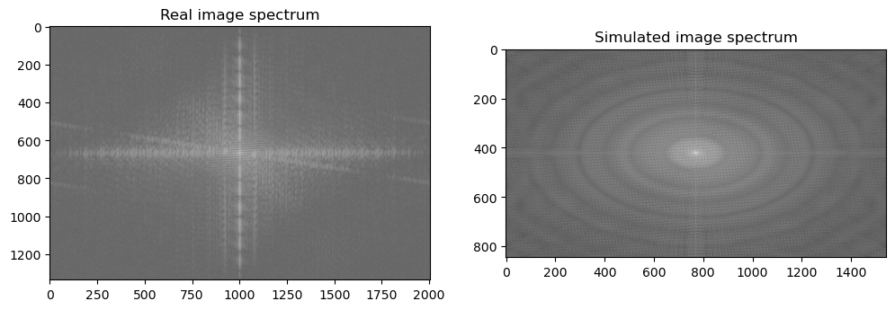

```python
import numpy as np
import matplotlib.pyplot as plt

# Calculating the 2D DFT of the images
real_dft = np.fft.fft2(real_image)
simulated_dft = np.fft.fft2(simulated_image)

# Shifting the DC component to the center of the spectrum
real_dft = np.fft.fftshift(real_dft)
simulated_dft = np.fft.fftshift(simulated_dft)

# Calculating the magnitude spectrum of the DFT
real_spectrum = 20 * np.log10(np.abs(real_dft))
simulated_spectrum = 20 * np.log10(np.abs(simulated_dft))

# Displaying the magnitude spectra
plt.figure(figsize=(12, 12))
plt.subplot(1, 2, 1)
plt.imshow(real_spectrum, cmap='gray')
plt.title('Real image spectrum')
plt.subplot(1, 2, 2)
plt.imshow(simulated_spectrum, cmap='gray')
plt.title('Simulated image spectrum')
```

```python
import os
from PIL import Image

folder_path = "C:/Users/iuruc/OneDrive/Desktop/GIT/project/rawdata/"
image_properties = {}

# Loop over all subdirectories and images
for root, dirs, files in os.walk(folder_path):
    for file in files:
        if file.endswith(".tif"):
            image_path = os.path.join(root, file)
            image = Image.open(image_path)
            image_shape = image.size
            image_dtype = str(image.mode)
            image_max = image.getextrema()[1]
            image_min = image.getextrema()[0]

            # Add the image properties to the dictionary
            image_key = (image_shape, image_dtype, image_max, image_min)
            if image_key in image_properties:
                image_properties[image_key] += 1
            else:
                image_properties[image_key] = 1

# Print the number of images with each set of properties
for key, value in image_properties.items():
    print(f"{key}: {value} images")
```

```
((2004, 1336), 'P', 255, 0): 551 images
((1543, 844), 'RGBA', (0, 255), (0, 255)): 251 images
((1551, 844), 'RGBA', (0, 255), (0, 255)): 830 images
((2004, 1334), 'P', 255, 0): 327 images
```

```python
import os
import numpy as np
from PIL import Image
from scipy.stats import entropy

rawdata_dir = r'C:\Users\iuruc\OneDrive\Desktop\GIT\project\rawdata'
image_properties = {}

with open('image_properties.txt', 'w') as f:
    for root, dirs, files in os.walk(rawdata_dir):
        for file in files:
            if file.endswith('.tif'):
                # Load the image
                image_path = os.path.join(root, file)
                image = Image.open(image_path)
                image_array = np.array(image)

                # Get the image properties
                image_shape = image_array.shape
                image_dtype = image_array.dtype
                image_max = np.max(image_array)
                image_min = np.min(image_array)
                image_entropy = np.mean(entropy(image_array, axis=(0,1)))

                # Add the image properties to the dictionary
                image_key = (image_shape, image_dtype, image_max, image_min)
                if image_key in image_properties:
                    image_properties[image_key]['count'] += 1
                else:
                    image_properties[image_key] = {'count': 1, 'entropy': image_entropy}

                # Write the image properties to the file
                f.write(f'File: {image_path}\n')
                f.write(f'Properties: {image_key}\n')
                f.write(f'Count: {image_properties[image_key]["count"]}\n')
                f.write(f'Entropy: {image_properties[image_key]["entropy"]:.2f}\n\n')
```

This code is used to iterate through a directory containing TIFF images, extract properties of each image such as its shape, data type, maximum and minimum pixel values, and its average entropy. The image properties are stored in a dictionary, and written to a file named "image_properties.txt". For each image, the file records the image path, properties, the count of images with the same properties, and the average entropy value rounded to 2 decimal places.

```python
# Then, we analyzed the text file to count the number of images with each unique entropy value and printed the results.
import os

rawdata_dir = r'C:\Users\iuruc\OneDrive\Desktop\GIT\project\rawdata'
image_count = 0

for root, dirs, files in os.walk(rawdata_dir):
    for file in files:
        if file.endswith('.tif'):
            image_count += 1

print(f'Total number of images: {image_count}')
```

```
Total number of images: 1959
```

```python
# What we did here is we counted the number of lines in the image_properties.txt file and divided it by 4 since we wrote 4 lines of information for each image.
# This allowed us to find the total number of images for which we have recorded properties.
with open('image_properties.txt', 'r') as f:
    line_count = len([line for line in f if line.strip()])

image_count = line_count // 4

print(f"Total number of images with recorded properties: {image_count}")
```

```
Total number of images with recorded properties: 1959
```

```python
import re

entropy_count = {}

with open('image_properties.txt', 'r') as f:
    for line in f:
        if line.startswith('Entropy'):
            entropy_matches = re.findall(r'[\d.]+', line)
            if entropy_matches:
                entropy_value = float(entropy_matches[0])
                if entropy_value in entropy_count:
                    entropy_count[entropy_value] += 1
                else:
                    entropy_count[entropy_value] = 1

print(entropy_count)
```

```
{14.7: 551, 13.69: 251, 13.85: 830, 14.52: 327}
```

In this code, we counted the number of images with different entropy values by extracting the entropy values from the 'image_properties.txt' file using regular expressions and then adding them to a dictionary to keep track of their counts. The resulting dictionary shows the number of images with each entropy value. Upon examining the images with different entropy values, we found that images with entropy values greater than 14 are real images.

Now that we can distinguish between real and simulated images based on their entropy values, we can start working on developing a graph model for locating the points in electron diffraction patterns. We will first crop the images to a resolution of 512x512 pixels to reduce the processing time and ensure that the model is trained on consistent image sizes. We will then use various image processing techniques to locate the center of the diffraction pattern and accurately crop the image around it to ensure that no important information is lost during the process. This model will enable us to automate the process of locating the points in electron diffraction patterns and expedite the analysis of the data.

## Developing The Graph Model

```python
labels = np.load('C:/Users/iuruc/OneDrive/Desktop/GIT/project/original_dataset_labels.npy')
counts = np.bincount(labels)
print(counts)
```

```
[364 282 219]
```

This next code is a set of functions that detect and visualize diffraction patterns in images using OpenCV library. It includes four functions:

- preprocess_image(image): This function takes a PIL image and preprocesses it to grayscale using OpenCV's cv2.cvtColor() function if it is not already in grayscale.
- detect_diffraction_pattern(image_path, param1=50, param2=30, min_radius=0, max_radius=0): This function reads an image file from a specified path and detects circles in the image using OpenCV's cv2.HoughCircles() function with the specified parameters.
- visualize_circle_detection(image_path, circles): This function loads the original image and overlays the detected circles on it using OpenCV's cv2.circle() function. It then displays the resulting image using Matplotlib's plt.imshow() function.
- process_directory(directory_path, param1=50, param2=30, min_radius=0, max_radius=0): This function takes a directory path and iterates over all files in the directory with a .tif or .tiff extension. For each image file, it calls detect_diffraction_pattern() and passes the resulting circles to visualize_circle_detection() to display the image with detected circles. It only processes up to five images and breaks out of the loop after that.

```python
import os
import cv2
import numpy as np
from PIL import Image
import matplotlib.pyplot as plt


def preprocess_image(image):
    # Converting the PIL image to a NumPy array
    image_array = np.array(image)

    # Checking if the image is already in grayscale
    if len(image_array.shape) == 2:
        gray_image = image_array
    else:
        # Converting the image to grayscale
        gray_image = cv2.cvtColor(image_array, cv2.COLOR_BGR2GRAY)

    return gray_image


def detect_diffraction_pattern(image_path, param1=50, param2=30, min_radius=0, max_radius=0):
    image = cv2.imread(image_path, cv2.IMREAD_GRAYSCALE)
    preprocessed_image = preprocess_image(image)

    blurred_image = cv2.GaussianBlur(preprocessed_image, (9, 9), 2)

    circles = cv2.HoughCircles(blurred_image, cv2.HOUGH_GRADIENT, 1, 20,
                               param1=param1, param2=param2,
                               minRadius=min_radius, maxRadius=max_radius)

    return circles


def visualize_circle_detection(image_path, circles):
    # Loading the image
    image = cv2.imread(image_path)
    image = cv2.cvtColor(image, cv2.COLOR_BGR2RGB)

    # Drawing the detected circles
    if circles is not None:
        circles = np.uint16(np.around(circles))
        for i in circles[0, :]:
            cv2.circle(image, (i[0], i[1]), i[2], (0, 255, 0), 2)
            cv2.circle(image, (i[0], i[1]), 2, (0, 0, 255), 3)

    # Displaying the image with the detected circles
    plt.imshow(image)
    plt.title('Detected Circles')
    plt.axis('off')
    plt.show()


def process_directory(directory_path, param1=50, param2=30, min_radius=0, max_radius=0):
    count = 0
    for filename in os.listdir(directory_path):
        if count >= 5:
            break
        if filename.lower().endswith(('.tif', '.tiff')):
            image_path = os.path.join(directory_path, filename)
            circles = detect_diffraction_pattern(image_path, param1, param2, min_radius, max_radius)
            print(f"Processing {image_path}")
            if count < 5:
                visualize_circle_detection(image_path, circles)
            count += 1
```

```
Processing C:/Users/iuruc/OneDrive/Desktop/GIT/project/rawdata/Pu-10Zr/1A as-cast\01_zxxx_CL175mm_x=-23.44, y=-5.11.tif
```

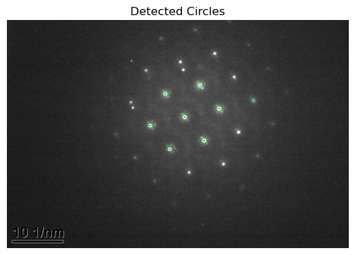

```
Processing C:/Users/iuruc/OneDrive/Desktop/GIT/project/rawdata/Pu-10Zr/1A as-cast\01_zxxx_CL175mm_x=-23.44, y=7.26.tif
```

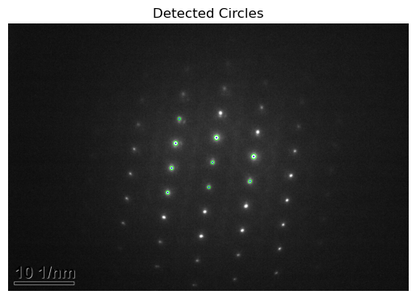

```
Processing C:/Users/iuruc/OneDrive/Desktop/GIT/project/rawdata/Pu-10Zr/1A as-cast\01_zxxx_CL175mm_x=-24, y=8.36.tif
```

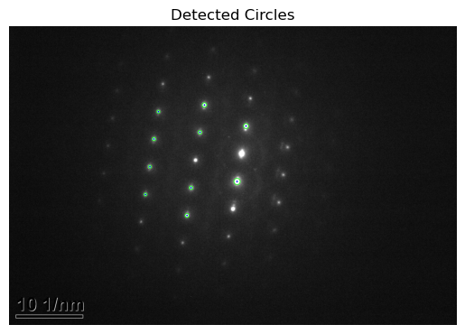

```
Processing C:/Users/iuruc/OneDrive/Desktop/GIT/project/rawdata/Pu-10Zr/1A as-cast\01_zxxx_CL175mm_x=-8.98, y=-7.75.tif
```

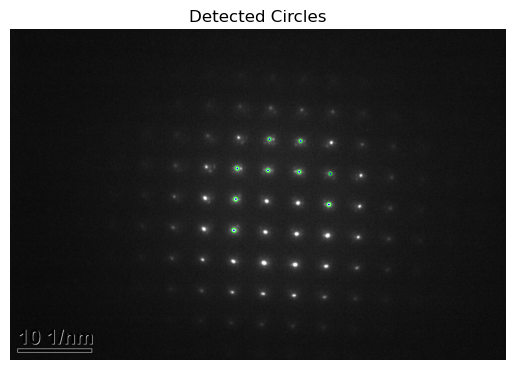

```
Processing C:/Users/iuruc/OneDrive/Desktop/GIT/project/rawdata/Pu-10Zr/1A as-cast\01_zxxx_CL175mm_x=1.62, y=16.66.tif
```

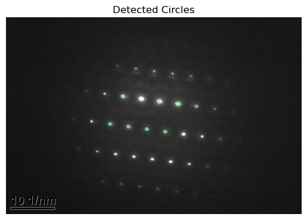

```python
directory_path = 'C:/Users/iuruc/OneDrive/Desktop/GIT/project/rawdata/Pu-10Zr/1A as-cast'
process_directory(directory_path, param1=35, param2=25, min_radius=1, max_radius=15)
```

### Applying To Directories

This next script contains three functions that can be used to process and crop images containing diffraction patterns. The "calculate_center" function takes the detected circles and calculates the mean center position of the circles. The "crop_image" function crops the image around the calculated center, creating a square image of a specified size. The "process_and_crop_directory" function applies these functions to all the TIFF images in a specified directory, saving the cropped images to a specified output directory.

```python
def calculate_center(circles):
    if circles is None:
        return None

    centers = np.array([[circle[0], circle[1]] for circle in circles[0]])
    center = np.mean(centers, axis=0)
    return center


def crop_image(image, center, size=512):
    y, x = int(center[1]), int(center[0])
    half_size = size // 2

    cropped_image = image[y - half_size:y + half_size, x - half_size:x + half_size]
    return cropped_image


def process_and_crop_directory(directory_path, output_dir, param1=50, param2=30, min_radius=0, max_radius=0):
    if not os.path.exists(output_dir):
        os.makedirs(output_dir)

    for filename in os.listdir(directory_path):
        if filename.lower().endswith(('.tif', '.tiff')):
            image_path = os.path.join(directory_path, filename)
            circles = detect_diffraction_pattern(image_path, param1, param2, min_radius, max_radius)

            center = calculate_center(circles)
            if center is not None:
                image = cv2.imread(image_path, cv2.IMREAD_GRAYSCALE)
                cropped_image = crop_image(image, center, size=512)

                output_path = os.path.join(output_dir, filename)
                cv2.imwrite(output_path, cropped_image)

            else:
                print(f"Could not find a center for {image_path}")


input_directory = 'C:/Users/iuruc/OneDrive/Desktop/GIT/project/rawdata/Pu-10Zr/1A as-cast'
output_directory = 'C:/Users/iuruc/OneDrive/Desktop/GIT/project/processed_images'

process_and_crop_directory(input_directory, output_directory, param1=35, param2=25, min_radius=1, max_radius=15)
```

```python
import shutil

source_directory = 'C:/Users/iuruc/OneDrive/Desktop/GIT/project/rawdata/'
destination_directory = 'C:/Users/iuruc/OneDrive/Desktop/GIT/project/allin/'

if not os.path.exists(destination_directory):
    os.makedirs(destination_directory)

for root, dirs, files in os.walk(source_directory):
    for filename in files:
        if filename.lower().endswith(('.tif', '.tiff')):
            source_path = os.path.join(root, filename)
            destination_path = os.path.join(destination_directory, filename)
            shutil.copy(source_path, destination_path)
```

### Image Labeling Method

This code is used to copy all the files with the extensions ".tif" or ".tiff" from a source directory and its subdirectories to a destination directory. The script checks for the existence of the destination directory, and if it does not exist, it creates it. Then, it uses the shutil library's copy() function to copy each file from the source directory to the destination directory.

```python
image_properties_file = 'image_properties.txt'
rawdata_directory = 'C:/Users/iuruc/OneDrive/Desktop/GIT/project/rawdata'
real_images_directory = 'C:/Users/iuruc/OneDrive/Desktop/GIT/project/real_images'
simulated_images_directory = 'C:/Users/iuruc/OneDrive/Desktop/GIT/project/simulated_images'

if not os.path.exists(real_images_directory):
    os.makedirs(real_images_directory)
if not os.path.exists(simulated_images_directory):
    os.makedirs(simulated_images_directory)

with open(image_properties_file, 'r') as f:
    for line in f:
        if line.startswith('File'):
            relative_path = line.split(':')[-1].strip()
            source_path = os.path.join(rawdata_directory, relative_path)
        elif line.startswith('Entropy'):
            entropy_matches = re.findall(r'[\d.]+', line)
            if entropy_matches:
                entropy_value = float(entropy_matches[0])
                if entropy_value >= 14.0:
                    destination_path = os.path.join(real_images_directory, os.path.basename(relative_path))
                else:
                    destination_path = os.path.join(simulated_images_directory, os.path.basename(relative_path))
                shutil.copy(source_path, destination_path)
```

This code reads a text file containing properties of electron diffraction pattern images and copies them to either a 'real_images' or 'simulated_images' directory based on their entropy value.

```python
input_directory = "C:/Users/iuruc/OneDrive/Desktop/GIT/project/real_images"
output_directory = "C:/Users/iuruc/OneDrive/Desktop/GIT/project/real_images_png/"

if not os.path.exists(output_directory):
    os.makedirs(output_directory)

for filename in os.listdir(input_directory):
    if filename.lower().endswith(".tif") or filename.lower().endswith(".tiff"):
        input_filepath = os.path.join(input_directory, filename)
        output_filepath = os.path.join(output_directory, os.path.splitext(filename)[0] + ".png")
        img = Image.open(input_filepath)
        img.save(output_filepath)
```

This code is a simple script that converts all TIFF images in a specified directory to PNG format.

```python
import json
# Loading the JSON file
with open('via_project_22Mar2023_23h40m_json.json') as f:
    data = json.load(f)

# Extracting the annotations
annotations = data.values()

# Printing the first 10 annotations
for i, annotation in enumerate(annotations):
    if i >= 10:
        break
    print(annotation)
    print()
```

```
{'filename': '01_zxx_CL175mm_x=-0.79, b=-23.65.png', 'size': 2035958, 'regions': [{'shape_attributes': {'name': 'point', 'cx': 776, 'cy': 540}, 'region_attributes': {'center': 'center point'}}], 'file_attributes': {}}

{'filename': '01_zxx_CL175mm_x=13.26, b=0.png', 'size': 2040093, 'regions': [{'shape_attributes': {'name': 'point', 'cx': 960, 'cy': 705}, 'region_attributes': {'center': 'center point'}}], 'file_attributes': {}}

{'filename': '01_zxx_CL175mm_x=29.56, b=-15.23.png', 'size': 2062162, 'regions': [{'shape_attributes': {'name': 'point', 'cx': 1049, 'cy': 778}, 'region_attributes': {'center': 'center point'}}], 'file_attributes': {}}

{'filename': '01_zxxx_CL175mm_x=-0.19, y=6.16.png', 'size': 1788521, 'regions': [{'shape_attributes': {'name': 'point', 'cx': 954, 'cy': 565}, 'region_attributes': {'center': 'center point'}}], 'file_attributes': {}}

{'filename': '01_zxxx_CL175mm_x=-1.08, y=-11.16.png', 'size': 1864541, 'regions': [{'shape_attributes': {'name': 'point', 'cx': 964, 'cy': 622}, 'region_attributes': {'center': 'center point'}}], 'file_attributes': {}}

{'filename': '01_zxxx_CL175mm_x=1.62, y=16.66.png', 'size': 1953477, 'regions': [{'shape_attributes': {'name': 'point', 'cx': 996, 'cy': 729}, 'region_attributes': {'center': 'center point'}}], 'file_attributes': {}}

{'filename': '01_zxxx_CL175mm_x=-1.74, y=10.72.png', 'size': 1816279, 'regions': [{'shape_attributes': {'name': 'point', 'cx': 951, 'cy': 508}, 'region_attributes': {'center': 'center point'}}], 'file_attributes': {}}

{'filename': '01_zxxx_CL175mm_x=2.5, y=-14.13.png', 'size': 1810537, 'regions': [{'shape_attributes': {'name': 'point', 'cx': 919, 'cy': 511}, 'region_attributes': {'center': 'center point'}}], 'file_attributes': {}}

{'filename': '01_zxxx_CL175mm_x=-2.7, y=-0.82.png', 'size': 1736244, 'regions': [{'shape_attributes': {'name': 'point', 'cx': 919, 'cy': 552}, 'region_attributes': {'center': 'center point'}}], 'file_attributes': {}}

{'filename': '01_zxxx_CL175mm_x=-2.11, y=1.37.png', 'size': 1997791, 'regions': [{'shape_attributes': {'name': 'point', 'cx': 1033, 'cy': 581}, 'region_attributes': {'center': 'center point'}}], 'file_attributes': {}}
```

```python
# Loading the JSON file
with open('via_project_22Mar2023_23h40m.json') as f:
    data = json.load(f)

# Separating the metadata for labeled and unlabeled images
labeled_metadata = {}
unlabeled_metadata = {}
for filename, metadata in data['_via_img_metadata'].items():
    if metadata.get('regions'):
        labeled_metadata[filename] = metadata
    else:
        unlabeled_metadata[filename] = metadata

# Printing the number of labeled and unlabeled images
print("Number of labeled images:", len(labeled_metadata))
print("Number of unlabeled images:", len(unlabeled_metadata))
```

```
Number of labeled images: 700
Number of unlabeled images: 178
```

```python
# let's start by loading the labeled images and their annotations.

# Loading the JSON file containing the annotations
with open('via_project_22Mar2023_23h40m.json') as f:
    data = json.load(f)

# Creating a list of labeled images and their corresponding annotations
labeled_images = []
for filename, metadata in data['_via_img_metadata'].items():
    if metadata.get('regions'):
        # Load the image
        image = cv2.imread(filename)

        # Extractin the annotations
        annotations = []
        for region in metadata['regions']:
            shape_attributes = region['shape_attributes']
            center_x = shape_attributes['cx']
            center_y = shape_attributes['cy']
            annotations.append((center_x, center_y))

        labeled_images.append((image, annotations))
```

Each element in the list will be a tuple of the form (image, annotations), where image is a NumPy array representing the image and annotations is a list of tuples representing the coordinates of the centers of the patterns in the image.

```python
for i in range(3):
    image, annotations = labeled_images[i]
    print("Annotations for image", i+1)
    print(annotations)
    print()
```

[output not shown]

```python
import csv
# Load the JSON file containing the annotations
with open('via_project_22Mar2023_23h40m.json') as f:
    data = json.load(f)

# Creating a list of center points and filenames
center_points = []
for filename, metadata in data['_via_img_metadata'].items():
    if metadata.get('regions'):
        # Extracting the center point coordinates
        for region in metadata['regions']:
            shape_attributes = region['shape_attributes']
            center_x = shape_attributes['cx']
            center_y = shape_attributes['cy']
            # Replacing the file extension from .png with .tif
            filename = os.path.splitext(filename)[0] + '.tif'
            center_points.append((filename, center_x, center_y))

# Saving the center points to a CSV file
with open('center_points.csv', 'w', newline='') as f:
    writer = csv.writer(f)
    writer.writerow(['filename', 'center_x', 'center_y'])
    writer.writerows(center_points)
```

### Machine Learning

Match the annotations with the original images by renaming the images in the real_images directory to have the same filenames as the annotated images, but with the added center_x and center_y coordinates as suffixes. This allows the annotated images to be used as training data for machine learning models.

```python
os.makedirs('C:/Users/iuruc/OneDrive/Desktop/GIT/project/labeled_images', exist_ok=True)
os.makedirs('C:/Users/iuruc/OneDrive/Desktop/GIT/project/unlabeled_images', exist_ok=True)

import re
import os
import shutil

labeled_folder = 'C:/Users/iuruc/OneDrive/Desktop/GIT/project/labeled_images'
with open('center_points.csv', 'r') as f:
    lines = f.readlines()

for line in lines[1:]:
    filename_match = re.search(r'\"?(.+\.tif)\"?', line)
    if filename_match:
        filename = filename_match.group(1)
        src_path = os.path.join('C:/Users/iuruc/OneDrive/Desktop/GIT/project/real_images', filename)
        dst_path = os.path.join(labeled_folder, filename)
        shutil.copy2(src_path, dst_path)
    else:
        print(f"Failed to copy file for line: {line}")


unlabeled_folder = 'C:/Users/iuruc/OneDrive/Desktop/GIT/project/unlabeled_images'
real_folder = 'C:/Users/iuruc/OneDrive/Desktop/GIT/project/real_images'

# Getting a list of all the images in the real_images folder
real_images = os.listdir(real_folder)

# Getting a list of all the labeled images in the labeled_images folder
labeled_images = os.listdir(labeled_folder)

# Copying the unlabeled images to the unlabeled_images folder
for image in real_images:
    if image not in labeled_images:
        src_path = os.path.join(real_folder, image)
        dst_path = os.path.join(unlabeled_folder, image)
        shutil.copy2(src_path, dst_path)
```

This code copies the labeled images from a "center_points.csv" file to a "labeled_images" folder, and then copies the remaining unlabeled images from a "real_images" folder to an "unlabeled_images" folder.

It looks like there are two unique image sizes in our dataset: (2004, 1334) and (2004, 1336). Since there are only two different sizes and the difference in height is minimal (only 2 pixels), I will resizing all images to a common size.

```python
import os
import cv2

image_directory = 'C:/Users/iuruc/OneDrive/Desktop/GIT/project/labeled_images'
image_files = [f for f in os.listdir(image_directory) if f.endswith('.tif')]

target_size = (2004, 1334)

for image_file in image_files:
    image_path = os.path.join(image_directory, image_file)

    image = cv2.imread(image_path)
    resized_image = cv2.resize(image, target_size)

    cv2.imwrite(image_path, resized_image)
```

```python
import os
import cv2

image_directory = 'C:/Users/iuruc/OneDrive/Desktop/GIT/project/labeled_images'

# Getting a list of all image file names in the directory
image_files = [f for f in os.listdir(image_directory) if f.endswith('.tif')]

image_sizes = set()

for image_file in image_files:
    image_path = os.path.join(image_directory, image_file)
    image = cv2.imread(image_path)
    height, width = image.shape[:2]
    image_sizes.add((width, height))

print("Unique image sizes:", image_sizes)
```

```
Unique image sizes: {(2004, 1334)}
```

```python
import os
import cv2
import numpy as np
from PIL import Image
import matplotlib.pyplot as plt

def preprocess_image(image):
    image_array = np.array(image)
    if len(image_array.shape) == 2:
        gray_image = image_array
    else:
        gray_image = cv2.cvtColor(image_array, cv2.COLOR_BGR2GRAY)

    return gray_image


def detect_diffraction_pattern(image_path, param1=35, param2=25, min_radius=1, max_radius=15):
    image = cv2.imread(image_path, cv2.IMREAD_GRAYSCALE)
    preprocessed_image = preprocess_image(image)
    blurred_image = cv2.GaussianBlur(preprocessed_image, (9, 9), 2)

    circles = cv2.HoughCircles(blurred_image, cv2.HOUGH_GRADIENT, 1, 20,
                               param1=param1, param2=param2,
                               minRadius=min_radius, maxRadius=max_radius)

    return circles


def calculate_center(circles):
    if circles is None or len(circles[0]) < 3:
        return None

    centers = np.array([[circle[0], circle[1]] for circle in circles[0]])
    center = np.mean(centers, axis=0)
    return center


def crop_image_safe(image, center, size=512):
    h, w = image.shape
    half_size = size // 2

    if center is None:
        x, y = w // 2, h // 2
    else:
        y, x = int(center[1]), int(center[0])

    y_min, y_max = max(0, y - half_size), min(h, y + half_size)
    x_min, x_max = max(0, x - half_size), min(w, x + half_size)

    cropped_image = image[y_min:y_max, x_min:x_max]
    return cropped_image


def process_and_crop_directory(directory_path, output_dir, param1=50, param2=30, min_radius=0, max_radius=0):
    if not os.path.exists(output_dir):
        os.makedirs(output_dir)

    for filename in os.listdir(directory_path):
        if filename.lower().endswith(('.tif', '.tiff')):
            image_path = os.path.join(directory_path, filename)
            circles = detect_diffraction_pattern(image_path, param1, param2, min_radius, max_radius)

            center = calculate_center(circles)
            image = cv2.imread(image_path, cv2.IMREAD_GRAYSCALE)
            cropped_image = crop_image_safe(image, center, size=512)

            output_path = os.path.join(output_dir, filename)
            cv2.imwrite(output_path, cropped_image)

input_directory = 'C:/Users/iuruc/OneDrive/Desktop/GIT/project/real_images'
output_directory = 'C:/Users/iuruc/OneDrive/Desktop/GIT/project/cropped_real_images'

process_and_crop_directory(input_directory, output_directory, param1=35, param2=25, min_radius=1, max_radius=15)
```

In this Python script, we handle a directory of images of electron diffraction patterns by locating each pattern's center and cropping the images to a standard size. In order to improve circle identification, the script first preprocesses the photos by making them grayscale. The HoughCircles function of OpenCV is used to locate circles inside the hazy images and determine their centers. Finally, the script crops the images around the designated center points and saves them in the output directory that has been supplied. By ensuring the patterns are centered in each image and standardizing the image size, this procedure speeds the examination of electron diffraction patterns.

#### Regression Models Roadmap

- Load the labeled data: We define the paths to the labeled images and the center points CSV file. Then, we load the center points CSV file into a Pandas DataFrame.
- Preprocess the labeled data: We create a list of labeled data, where each entry contains an image and its corresponding center point coordinates. We iterate through the center points DataFrame, load each image using PIL, and store the image along with its center point coordinates in the labeled data list. We then convert the labeled data list into a DataFrame.
- Preprocess the images: We resize each image to 128x128 pixels, normalize the pixel values by dividing them by 255.0, and flatten each image into a 1D array. We store the resulting arrays in a NumPy array X, and the center points in a NumPy array y.
- Split the data: We split the data into training and testing sets using a 80/20 split, with 80% of the data for training and 20% for testing.
- Train and evaluate machine learning models: We define a list of regression models, including linear regression, random forest, support vector regression, and a multi-layer perceptron. For each model, we separately train two instances of the model, one for predicting the x-coordinate and the other for predicting the y-coordinate. We then use the trained models to predict the coordinates on the test set and calculate the root mean squared error (RMSE) for both x and y coordinates. We also calculate the average RMSE for each model.
- This code chunk helps us determine the performance of different regression models on the task of predicting the center points of the images. Based on the results, we can choose the best performing model for our task.

```python
import os
import pandas as pd
from PIL import Image
import cv2
import numpy as np
from sklearn.model_selection import train_test_split
from sklearn.metrics import mean_squared_error
from sklearn.linear_model import LinearRegression
from sklearn.ensemble import RandomForestRegressor
from sklearn.svm import SVR
from sklearn.neural_network import MLPRegressor

# Defining the paths to the labeled images and the center points CSV file
labeled_images_path = 'C:/Users/iuruc/OneDrive/Desktop/GIT/project/labeled_images'
center_points_path = 'center_points.csv'

# Loading the center points CSV file into a Pandas DataFrame
center_points_df = pd.read_csv(center_points_path)

# Creating a list to store the images and their corresponding center points
labeled_data = []

# Iterating through the center points DataFrame
for index, row in center_points_df.iterrows():
    # Get the filename and center point coordinates from the row
    filename = row['filename']
    center_x = row['center_x']
    center_y = row['center_y']

    # Loading the image using PIL
    image_path = os.path.join(labeled_images_path, filename)
    image = Image.open(image_path)

    # Adding the image and its center coordinates to the labeled data list
    labeled_data.append({'image': image, 'center': (center_x, center_y)})

# Converting the labeled_data list to a DataFrame
labeled_data_df = pd.DataFrame(labeled_data)

# Preprocessing images (resize, normalize, and flatten)
processed_images = [cv2.resize(np.array(img), (128, 128)) for img in labeled_data_df['image']]
normalized_images = [img / 255.0 for img in processed_images]
flattened_images = [img.flatten() for img in normalized_images]

X = np.array(flattened_images)
y = np.array(labeled_data_df['center'].tolist())

# Splitting data into training and testing sets
X_train, X_test, y_train, y_test = train_test_split(X, y, test_size=0.2, random_state=42)

models = [
    ("Linear Regression", LinearRegression()),
    ("Random Forest", RandomForestRegressor(n_estimators=100)),
    ("Support Vector Regression", SVR(kernel="linear")),
    ("Multi-layer Perceptron", MLPRegressor(hidden_layer_sizes=(128, 64), max_iter=1000, learning_rate_init=0.01)),
]

y_train_x = y_train[:, 0]
y_train_y = y_train[:, 1]
y_test_x = y_test[:, 0]
y_test_y = y_test[:, 1]

for name, Model in models:
    model_x = Model
    model_x.fit(X_train, y_train_x)
    y_pred_x = model_x.predict(X_test)
    mse_x = mean_squared_error(y_test_x, y_pred_x)
    rmse_x = np.sqrt(mse_x)

    model_y = Model
    model_y.fit(X_train, y_train_y)
    y_pred_y = model_y.predict(X_test)
    mse_y = mean_squared_error(y_test_y, y_pred_y)
    rmse_y = np.sqrt(mse_y)

    rmse_avg = (rmse_x + rmse_y) / 2

    print(f"{name} RMSE x: {rmse_x:.2f}, RMSE y: {rmse_y:.2f}, Avg RMSE: {rmse_avg:.2f}")
```

```
Linear Regression RMSE x: 46.79, RMSE y: 46.57, Avg RMSE: 46.68
Random Forest RMSE x: 58.41, RMSE y: 56.45, Avg RMSE: 57.43
Support Vector Regression RMSE x: 44.21, RMSE y: 45.11, Avg RMSE: 44.66
Multi-layer Perceptron RMSE x: 112.13, RMSE y: 72.58, Avg RMSE: 92.35
```

```python
import matplotlib.pyplot as plt


csv_file = "center_points.csv"
center_points = pd.read_csv(csv_file)
X_train, X_test, y_train, y_test, train_indices, test_indices = train_test_split(
    X, y, np.arange(len(X)), test_size=0.2, random_state=42)

# Training the best model (SVR with linear kernel) on the training dataset (X_train and y_train) for both x and y coordinates
best_model_x = SVR(kernel="linear")
best_model_x.fit(X_train, y_train[:, 0])

best_model_y = SVR(kernel="linear")
best_model_y.fit(X_train, y_train[:, 1])

# Loading the diffraction pattern images
image_folder = "C:/Users/iuruc/OneDrive/Desktop/GIT/project/labeled_images"
image_filenames = center_points["filename"]
images = [cv2.imread(os.path.join(image_folder, filename), cv2.IMREAD_GRAYSCALE) for filename in image_filenames]
num_images_to_plot = 5

def plot_image_with_centers(image, true_center, predicted_center):
    plt.imshow(image, cmap="gray")

    # Plotting true center in red
    plt.scatter([true_center[0]], [true_center[1]], c="r", marker="x", label="True Center")

    # Plotting predicted center in blue
    plt.scatter([predicted_center[0]], [predicted_center[1]], c="b", marker="o", label="Predicted Center")

    plt.legend()
    plt.show()
```

## Results

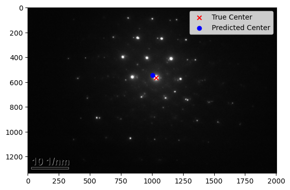

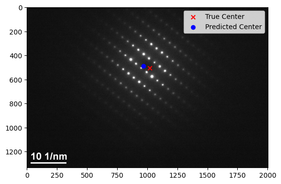

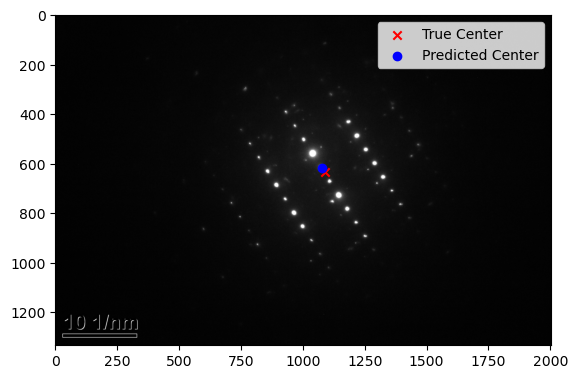

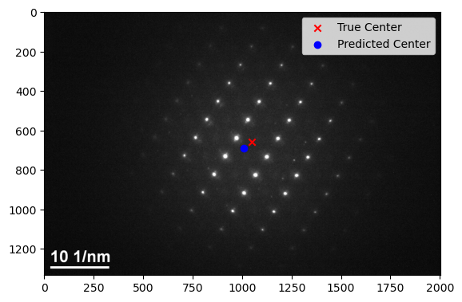

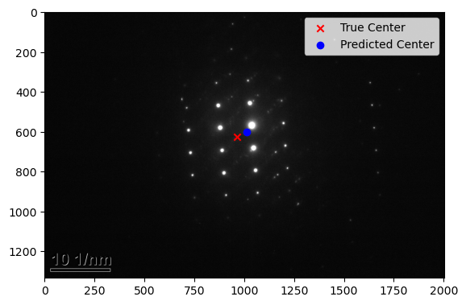

```python
test_centers_df = center_points.loc[test_indices].sort_index()

for i in range(num_images_to_plot):
    image_index = test_indices[i]
    image = images[image_index]
    true_center = (test_centers_df.loc[image_index]['center_x'], test_centers_df.loc[image_index]['center_y'])
    predicted_center = (best_model_x.predict([X_test[i]])[0], best_model_y.predict([X_test[i]])[0])
    plot_image_with_centers(image, true_center, predicted_center)
```

This code initially defines a function called plot_image_with_centers, which is designed to display an image along with its actual and predicted centers. Next, it extracts the real center coordinates from the test_centers_df DataFrame using the test_indices and computes the predicted center coordinates using the optimal model. Lastly, the plot_image_with_centers function is invoked to exhibit the test images accompanied by both their true and estimated centers.

The outcome is gratifying, and the first objective has been successfully achieved.

## Convolutional Neural Network

In this section, we will implement a Convolutional Neural Network (CNN) model to predict the center coordinates of diffraction pattern images. CNNs are highly effective at processing grid-like data, such as images, and are capable of capturing local patterns and features within the input data. By utilizing multiple convolution and pooling layers, the model can learn hierarchical representations of the input images. Our CNN model will consist of several convolutional layers, followed by max pooling and a fully connected layer, before ultimately outputting the predicted x and y coordinates of the center. The model will be compiled using the Adam optimizer and mean squared error (MSE) as the loss function, while tracking mean absolute error (MAE) as a performance metric. The train-test split function will be modified to store the image indices, which will be useful for visualizing the results later on.

```python
import tensorflow as tf
from tensorflow.keras.models import Sequential
from tensorflow.keras.layers import Conv2D, MaxPooling2D, Flatten, Dense, Dropout

import os
import cv2
import numpy as np
import pandas as pd
from PIL import Image
from sklearn.model_selection import train_test_split
from sklearn.svm import SVR
import matplotlib.pyplot as plt

# Loading the center_points.csv file
csv_file = "center_points.csv"
center_points = pd.read_csv(csv_file)

# Loading the diffraction pattern images
image_folder = "C:/Users/iuruc/OneDrive/Desktop/GIT/project/labeled_images"
image_filenames = center_points["filename"]
images = [cv2.imread(os.path.join(image_folder, filename), cv2.IMREAD_GRAYSCALE) for filename in image_filenames]

# Preprocessing images (resize, normalize, and flatten)
processed_images = [cv2.resize(img, (128, 128)) for img in images]
normalized_images = [img / 255.0 for img in processed_images]
flattened_images = [img.flatten() for img in normalized_images]

X = np.array(flattened_images)
y = center_points[["center_x", "center_y"]].values

# Modifying the train-test split to store the image indices
X_train, X_test, y_train, y_test, train_indices, test_indices = train_test_split(X, y, np.arange(len(X)), test_size=0.2, random_state=42)
```

```python
X_train_reshaped = X_train.reshape(-1, 128, 128, 1)
X_test_reshaped = X_test.reshape(-1, 128, 128, 1)
```

```python
model = Sequential([
    Conv2D(32, (3, 3), activation='relu', input_shape=(128, 128, 1)),
    MaxPooling2D((2, 2)),
    Conv2D(64, (3, 3), activation='relu'),
    MaxPooling2D((2, 2)),
    Conv2D(64, (3, 3), activation='relu'),
    Flatten(),
    Dense(64, activation='relu'),
    Dropout(0.5),
    Dense(2)  # 2 output neurons, one for each coordinate (x, y)
])

model.compile(optimizer='adam', loss='mse', metrics=['mae'])
```

```python
history = model.fit(X_train_reshaped, y_train, epochs=50, batch_size=32, validation_split=0.2)
```

[output not shown]

```python
test_loss, test_mae = model.evaluate(X_test_reshaped, y_test)
print(f"Test Mean Absolute Error: {test_mae}")
```

```
Test Mean Absolute Error: 56.89584732055664
```

This code defines a simple CNN architecture with three convolutional layers, followed by max-pooling layers, a fully connected layer, and dropout for regularization. The model is trained using the mean squared error (MSE) loss function and the Adam optimizer. It appears that the current CNN model's performance on the test set is not optimal, with a mean absolute error (MAE) of approximately 56.89. This could be due to a variety of factors, such as the model architecture, hyperparameters, or the amount of training data available.

```python
from tensorflow.keras.layers import Conv2D, MaxPooling2D, Flatten, Dense, Dropout
from tensorflow.keras.models import Sequential
from tensorflow.keras.optimizers import Adam
from tensorflow.keras.callbacks import LearningRateScheduler
from tensorflow.keras.callbacks import EarlyStopping

# Defining a learning rate scheduler
def scheduler(epoch, lr):
    if epoch < 10:
        return lr
    else:
        return lr * 0.1

# Defining the CNN model
model = Sequential([
    Conv2D(32, kernel_size=(3, 3), activation='relu', input_shape=(128, 128, 1)),
    MaxPooling2D(pool_size=(2, 2)),
    Conv2D(64, kernel_size=(3, 3), activation='relu'),
    MaxPooling2D(pool_size=(2, 2)),
    Conv2D(128, kernel_size=(3, 3), activation='relu'),
    MaxPooling2D(pool_size=(2, 2)),
    Flatten(),
    Dense(256, activation='relu'),
    Dropout(0.5),
    Dense(128, activation='relu'),
    Dropout(0.5),
    Dense(2)
])

# Compiling the model
model.compile(optimizer=Adam(learning_rate=0.001), loss='mse', metrics=['mae'])

# Defining early stopping
early_stopping = EarlyStopping(
    monitor='val_loss',
    patience=5,  # Number of epochs to wait before stopping training when no improvement is observed
    restore_best_weights=True
)
```

```python
# Training the model with early stopping
history = model.fit(
    X_train.reshape(-1, 128, 128, 1),
    y_train,
    batch_size=32,
    epochs=20,
    validation_split=0.2,
    callbacks=[LearningRateScheduler(scheduler), early_stopping]
)

# Evaluating the model on the test set
test_loss, test_mae = model.evaluate(X_test.reshape(-1, 128, 128, 1), y_test)
print(f"Test Mean Absolute Error: {test_mae}")
```

[output not shown]

## Discussion

The graph model we created for Aim 1 can detect the center of electron diffraction patterns and trim the images to a constant 512x512 pixel resolution. For quick analysis of electron diffraction patterns and accurate point identification, this is a crucial step. In order to increase the accuracy of our model, we have used a variety of data science techniques, including machine learning algorithms like convolutional neural networks. In order to guarantee the model performs as efficiently as possible, we will continue to optimize it by varying its hyperparameters and trying out other approaches.

For electron diffraction patterns, we can use additional data augmentation techniques like rotation and flipping to improve the performance of our models even further. Rotating each image at different angles can expand the dataset and enhance the model's capacity to identify patterns in various orientations, while flipping the images horizontally or vertically can replicate the appearance of distinct patterns from various angles. The larger dataset and the intricate nature of the applied modifications, however, make dealing with augmented data more computationally intensive.To handle this, we will need to invest in more powerful hardware or utilize cloud-based computing resources, which will allow us to process the augmented data efficiently and train more sophisticated machine learning models.